# University of Illinois - Urbana-Champaign

```r
# Load data

zip_cbsa_data <- read_csv(url('https://raw.githubusercontent.com/cyouh95/third-way-report/master/assets/data/zip_code_cbsa.csv'))
hs_data <- read_csv(url('https://github.com/cyouh95/third-way-report/blob/master/assets/data/hs_data.csv?raw=true'), col_types = c('zip_code' = 'c'))

ceeb_nces <- read_csv(url('https://github.com/mpatricia01/public_requests_eda/raw/main/data/ceeb_nces_crosswalk.csv'))
cds_nces <- read_csv(url('https://github.com/mpatricia01/public_requests_eda/raw/main/data/CDS_NCES_crosswalk.csv')) %>%
  mutate(ncessch = str_c(NCESDist, NCESSchool))

load(url('https://github.com/mpatricia01/public_requests_eda/raw/main/data/145637_orders.RData'))
# Contains: IL_orders, OOS_orders, OOS_eng_orders, OOS_noneng_orders, intl_orders,
#           lists_df_pivot, lists_df_sat, lists_df_act, df_sat_ca_20, df_sat_ca_19, hs_tract_ca

# Add 11 + 12 columns for the SAT test takers datasets
add_testtakers_cols <- function(sat_df) {
  sat_df %>% mutate(
    Enroll1112 = as.numeric(Enroll12) + as.numeric(Enroll11),
    NumTSTTakr1112 = NumTSTTakr11 + NumTSTTakr12,
    NumERWBenchmark1112 = as.numeric(NumERWBenchmark11) + as.numeric(NumERWBenchmark12),
    PctERWBenchmark1112 = as.numeric(NumERWBenchmark1112) / as.numeric(NumTSTTakr1112),
    NumMathBenchmark1112 = as.numeric(NumMathBenchmark11) + as.numeric(NumMathBenchmark12),
    PctMathBenchmark1112 = as.numeric(NumMathBenchmark1112) / as.numeric(NumTSTTakr1112),
    TotNumBothBenchmark1112 = as.numeric(TotNumBothBenchmark11) + as.numeric(TotNumBothBenchmark12),
    PctBothBenchmark1112 = as.numeric(TotNumBothBenchmark1112) / as.numeric(NumTSTTakr1112)
  )
}

df_sat_ca_20 <- add_testtakers_cols(df_sat_ca_20)
df_sat_ca_19 <- add_testtakers_cols(df_sat_ca_19)
```

# 1 Illinois purchases (51 orders)

```r
IL_orders
```

| univ_id | po_num | order_num | order_title | order_cost | num_runs | num_students | date_start | date_end | hs_grad_class | state_name | cbsa_name | race_ethnicity | sat_score_min | sat_score_max | sat_score_old_min | sat_score_old_max | psat_score_min | psat_score_max | psat_score_old_min | psat_score_old_max | gpa_high | gpa_low | rank_high | rank_low |
| --- | --- | --- | --- | --- | --- | --- | --- | --- | --- | --- | --- | --- | --- | --- | --- | --- | --- | --- | --- | --- | --- | --- | --- | --- |
| 145637 | P1558959 | 327699 | IL Lower Range August 2017 | 4610.89 | NA | 10723 | 2017-10-12 |  | 2018\|2019\|2020 | Illinois | NA | Asian (including Indian subcontinent and Philippines origin)\|Other\|I do not wish to respond to race\|No, not of Hispanic, Latino, or Spanish origin\|White (including Middle Eastern origin)\|Native H… | 1160 | 1270 | 1090 | 1200 | 1160 | 1270 | 109 | 120 | A+ | B- | Highest tenth | Second fifth |
| 145637 | P1558959 | 327649 | IL Middle 50% August 2017 | 1761.71 | NA | 4097 | 2017-10-12 |  | 2018\|2019\|2020 | Illinois | NA | Asian (including Indian subcontinent and Philippines origin)\|Other\|I do not wish to respond to race\|No, not of Hispanic, Latino, or Spanish origin\|White (including Middle Eastern origin)\|Native H… | 1280 | 1440 | 1210 | 1390 | 1280 | 1440 | 121 | 139 | A+ | B- | Highest tenth | Second fifth |
| 145637 | P1558959 | 327696 | IL 1450+ August 2017 | 241.23 | NA | 561 | 2017-10-12 |  | 2018\|2019\|2020 | Illinois | NA | Asian (including Indian subcontinent and Philippines origin)\|Other\|I do not wish to respond to race\|No, not of Hispanic, Latino, or Spanish origin\|White (including Middle Eastern origin)\|Native H… | 1450 | 1600 | 1400 | 1600 | 1450 | 1520 | 140 | 149 | A+ | B- | Highest tenth | Second fifth |
| 145637 | P1558959 | 327681 | URM Lower Range August 2017 | 2858.64 | NA | 6648 | 2017-10-12 |  | 2018\|2019\|2020 | Illinois | NA | Black or African American\|American Indian or Alaska Native\|Other Hispanic or Latino\|Puerto Rican\|Mexican\|Hispanic or Latino (including Spanish origin)\|Cuban | 1020 | 1190 | 940 | 1120 | 1020 | 1190 | 94 | 112 | A+ | B- | Highest tenth | Second fifth |
| 145637 | P1558959 | 327700 | PAP Traditional August 2017 | 109.65 | NA | 255 | 2017-10-12 |  | 2018\|2019\|2020 | Illinois | NA | Black or African American\|American Indian or Alaska Native\|Other Hispanic or Latino\|Puerto Rican\|Mexican\|Hispanic or Latino (including Spanish origin)\|Cuban | 1200 | 1380 | 1130 | 1320 | 1200 | 1380 | 113 | 132 | A+ | B- | Highest tenth | Second fifth |
| 145637 | P1558959 | 327630 | PAP Honors August 2017 | 11.61 | NA | 27 | 2017-10-12 |  | 2018\|2019\|2020 | Illinois | NA | Black or African American\|American Indian or Alaska Native\|Other Hispanic or Latino\|Puerto Rican\|Mexican\|Hispanic or Latino (including Spanish origin)\|Cuban | 1390 | 1600 | 1330 | 1600 | 1390 | 1520 | 133 | 149 | A+ | B- | Highest tenth | Second fifth |
| 145637 | P1558959 | 371076 | IL 1160-1270 Feb 2018 | 4849.11 | NA | 11277 | 2018-02-06 |  | 2019\|2021\|2020 | Illinois | NA | Asian (including Indian subcontinent and Philippines origin)\|Other\|I do not wish to respond to race\|No, not of Hispanic, Latino, or Spanish origin\|White (including Middle Eastern origin)\|Native H… | 1160 | 1270 | 1090 | 1200 | 1160 | 1270 | 109 | 120 | A+ | B- | Highest tenth | Second fifth |
| 145637 | P1558959 | 371072 | IL 1280-1440 Feb 2018 | 1818.90 | NA | 4230 | 2018-02-06 |  | 2019\|2021\|2020 | Illinois | NA | Asian (including Indian subcontinent and Philippines origin)\|Other\|I do not wish to respond to race\|No, not of Hispanic, Latino, or Spanish origin\|White (including Middle Eastern origin)\|Native H… | 1280 | 1440 | 1210 | 1390 | 1280 | 1440 | 121 | 139 | A+ | B- | Highest tenth | Second fifth |
| 145637 | P1558959 | 371132 | IL 1450+ Feb 2018 | 217.58 | NA | 506 | 2018-02-06 |  | 2019\|2021\|2020 | Illinois | NA | Asian (including Indian subcontinent and Philippines origin)\|Other\|I do not wish to respond to race\|No, not of Hispanic, Latino, or Spanish origin\|White (including Middle Eastern origin)\|Native H… | 1450 | 1600 | 1400 | 1600 | 1450 | 1520 | 140 | 149 | A+ | B- | Highest tenth | Second fifth |
| 145637 | P1558959 | 371079 | URM 1020-1190 Feb 2018 | 2669.01 | NA | 6207 | 2018-02-06 |  | 2019\|2021\|2020 | Illinois | NA | Black or African American\|American Indian or Alaska Native\|Other Hispanic or Latino\|Puerto Rican\|Mexican\|Hispanic or Latino (including Spanish origin)\|Cuban | 1020 | 1190 | 940 | 1120 | 1020 | 1190 | 94 | 112 | A+ | B- | Highest tenth | Second fifth |

[output cut: 41 more lines]

Generally, on each purchase date, they make **6 IL orders by race/ethnicity and test scores**:

- Race/ethnicity groups (A) + Test score range (low A)
- Race/ethnicity groups (A) + Test score range (med A)
- Race/ethnicity groups (A) + Test score range (high A)
- Race/ethnicity groups (B) + Test score range (low B)
- Race/ethnicity groups (B) + Test score range (med B)
- Race/ethnicity groups (B) + Test score range (high B)

**Group/filter definitions**:

- **Race/ethnicity groups (A)**
  - Asian (including Indian subcontinent and Philippines origin)|Other|I do not wish to respond to race|No, not of Hispanic, Latino, or Spanish origin|White (including Middle Eastern origin)|Native Hawaiian or Other Pacific Islander
    - Starting from **Fall 2019**, they removed “*Native Hawaiian or Other Pacific Islander*” from the **med** and **high** orders
    - In the most recent 2 rounds of purchases (**6 orders** from **Dec 2019** & **Apr 2020**), they further limited geographic filter to 12 specific metro areas within IL
  - **Test score range (low A)**: 1160 - 1270
  - **Test score range (med A)**: 1260/1280 - 1440
  - **Test score range (high A)**: 1450 - 1600
- **Race/ethnicity groups (B)**
  - Black or African American|American Indian or Alaska Native|Other Hispanic or Latino|Puerto Rican|Mexican|Hispanic or Latino (including Spanish origin)|Cuban
    - Starting from **Fall 2019**, they added “*Native Hawaiian or Other Pacific Islander*” to all orders (**low**, **med**, and **high**)
  - **Test score range (low B)**: 1020/1030 - 1190
  - **Test score range (med B)**: 1200 - 1350/1380
  - **Test score range (high B)**: 1360/1390 - 1600

**Common filters**:

- **GPA**: A+ to B-
- **Class rank**: Highest tenth to second fifth

[interactive chart not shown]

# 2 Out-of-states purchases (22 orders)

Based on geographic filters, we can categorize their orders into **3 broad categories**:

- Specific MSAs (3 orders)
- Non-engineering majors in specific MSAs + CA, CT, MO, and Armed Forces military districts (6 orders)
- Engineering majors in all 49 states except IL + DC (13 orders)

21 of the 22 out-of-state orders also use these [segment analysis](http://secure-media.collegeboard.org/mSSS/media/pdf/segment-analysis-service-overview.pdf) filters (total possible: *33 neighborhood clusters* and *29 high-school clusters*):

- **EN**:51, **HS**:65 | **EN**:51, **HS**:68 | **EN**:51, **HS**:70 | **EN**:51, **HS**:79
- **EN**:53, **HS**:65 | **EN**:53, **HS**:70 |
- **EN**:58, **HS**:64 | **EN**:58, **HS**:65 | **EN**:58, **HS**:70
- **EN**:60, **HS**:65 | **EN**:60, **HS**:68 | **EN**:60, **HS**:70 | **EN**:60, **HS**:79
- **EN**:61, **HS**:ALL
- **EN**:63, **HS**:65 | **EN**:63, **HS**:70
- **EN**:69, **HS**:68 | **EN**:69, **HS**:70 | **EN**:69, **HS**:75
- **EN**:70, **HS**:66 | **EN**:70, **HS**:68 | **EN**:70, **HS**:70 | **EN**:70, **HS**:79
- **EN**:73, **HS**:65 | **EN**:73, **HS**:70
- **EN**:78, **HS**:ALL

Sample **neighborhood clusters (EN)** characteristics from 2011:

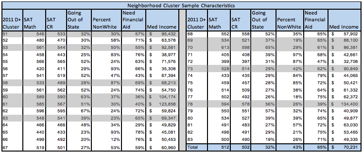

Sample **high school clusters (HS)** characteristics from 2011:

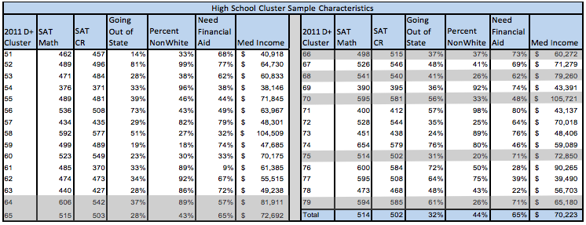

## 2.1 MSA orders (3 orders)

```r
OOS_msa_orders <- OOS_orders %>% filter(order_num %in% c('500590', '567376', '483751'))

OOS_msa_orders
```

| univ_id | po_num | order_num | order_title | order_cost | num_runs | num_students | date_start | hs_grad_class | state_name | cbsa_name | segment | gender | sat_score_min | sat_score_max | sat_score_old_min | sat_score_old_max | psat_score_min | psat_score_max | psat_score_old_min | psat_score_old_max | gpa_high | gpa_low |
| --- | --- | --- | --- | --- | --- | --- | --- | --- | --- | --- | --- | --- | --- | --- | --- | --- | --- | --- | --- | --- | --- | --- |
| 145637 | P1887010 | 500590 | OOS Regional MSAs | 11272.95 | 4 | 23985 | 2019-09-04 | 2021\|2020\|2023\|2022 | NA | NY - Syracuse, NY\|FL - Orlando-Kissimmee-Sanford, FL\|FL - Sebring, FL\|GA - Warner Robins, GA\|GA - Dalton, GA\|CA - Bakersfield, CA\|TX - San Angelo, TX\|TX - College Station-Bryan, TX\|GA - Valdos… | EN:51, HS:68\|EN:58, HS:70\|EN:53, HS:70\|EN:51, HS:65\|EN:69, HS:70\|EN:60, HS:68\|EN:73, HS:70\|EN:60, HS:65\|EN:69, HS:68\|EN:70, HS:68\|EN:63, HS:70\|EN:70, HS:66\|EN:78, HS:ALL\|EN:58, HS:65\|EN:… | NA | 1240 | 1450 | 1170 | 1400 | 1220 | 1450 | 115 | 140 | A+ | B- |
| 145637 | P1887010 | 567376 | OOS Regional MSAs | 10979.67 | NA | 23361 | 2020-04-03 | 2021\|2023\|2022 | NA | NY - Syracuse, NY\|FL - Orlando-Kissimmee-Sanford, FL\|FL - Sebring, FL\|GA - Warner Robins, GA\|GA - Dalton, GA\|CA - Bakersfield, CA\|TX - San Angelo, TX\|TX - College Station-Bryan, TX\|GA - Valdos… | EN:51, HS:68\|EN:58, HS:70\|EN:53, HS:70\|EN:51, HS:65\|EN:69, HS:70\|EN:60, HS:68\|EN:73, HS:70\|EN:60, HS:65\|EN:69, HS:68\|EN:70, HS:68\|EN:63, HS:70\|EN:70, HS:66\|EN:78, HS:ALL\|EN:58, HS:65\|EN:… | NA | 1240 | 1450 | 1170 | 1400 | 1220 | 1450 | 115 | 140 | A+ | B- |
| 145637 | P1659111 | 483751 | Regional Counselor MSAs | 673.65 | NA | 1497 | 2019-06-27 | 2021\|2022 | NA | FL - Orlando-Kissimmee-Sanford, FL\|FL - Sebring, FL\|GA - Warner Robins, GA\|GA - Dalton, GA\|CA - Bakersfield, CA\|TX - San Angelo, TX\|TX - College Station-Bryan, TX\|GA - Valdosta, GA\|FL - Palm B… | EN:51, HS:68\|EN:58, HS:70\|EN:53, HS:70\|EN:51, HS:65\|EN:69, HS:70\|EN:60, HS:68\|EN:73, HS:70\|EN:60, HS:65\|EN:69, HS:68\|EN:70, HS:68\|EN:63, HS:70\|EN:70, HS:66\|EN:78, HS:ALL\|EN:58, HS:65\|EN:… | NA | 1240 | 1450 | 1170 | 1400 | 1240 | 1450 | 117 | 140 | A+ | B- |

They made **2** “OOS Regional MSA” orders **1** “Regional Counselor MSAs” order.

- They used the segment analysis from above
- A+/B- high school GPA
- MSAs from states: CA, TX, GA, FL, NY, NJ

[interactive chart not shown]

### 2.1.1 Student-level MSA specific orders

Number of students purchased in the three orders

```r
OOS_msa_stu %>% count(order_num) %>% arrange(-n)
```

| order_num | n |
| --- | --- |
| 500590 | 35058 |
| 567376 | 23356 |
| 483751 | 1497 |

It appears that 4 students might of been purchased twice

```r
OOS_msa_stu %>%
  group_by(Ref, order_num) %>%
  summarize(n_per_grp = n()) %>%
  ungroup() %>%
  count(n_per_grp)
```

| n_per_grp | n |
| --- | --- |
| 1 | 59903 |
| 2 | 4 |

```r
OOS_msa_stu %>%
  group_by(Ref, order_num) %>%
  summarize(n_per_grp = n()) %>%
  ungroup() %>%
  filter(n_per_grp > 1) #4 students were purchased twice
```

| Ref | order_num | n_per_grp |
| --- | --- | --- |
| 058607977 | 567376 | 2 |
| 058918440 | 567376 | 2 |
| 313230561 | 567376 | 2 |
| 964290266 | 500590 | 2 |

This table below shows the number of zip codes purchased by descending order

- Grouped by zip code and summarized to get a count of the number of students purchased within each zip code
- Merged in census zip-code level data to show demographic data associated with each zip code

```r
OOS_msa_zip %>%
  dplyr::select(zip_code, n_per_grp, median_household_income, starts_with("pct"))
```

| zip_code | n_per_grp | median_household_income | pct_black | pct_white | pct_asian | pct_latinx | pct_nat_am | pct_nat_hi | pct_two_races | pct_other |
| --- | --- | --- | --- | --- | --- | --- | --- | --- | --- | --- |
| 77494 | 565 | 137231 | 0.08075680665 | 0.52277086 | 0.1722914423 | 0.1970055889 | 0.00743475363 | 0.00000000000 | 0.0181202892 | 0.00162026355 |
| 77479 | 485 | 133200 | 0.07150875880 | 0.39739692 | 0.4209720046 | 0.0858923685 | 0.00045606567 | 0.00000000000 | 0.0217508244 | 0.00202306055 |
| 94582 | 331 | 140210 | 0.02577854671 | 0.30402867 | 0.5536826495 | 0.0590212556 | 0.00086505190 | 0.00457241720 | 0.0507414731 | 0.00130993574 |
| 77382 | 318 | 136957 | 0.01866904400 | 0.72106560 | 0.0588389533 | 0.1846452357 | 0.00000000000 | 0.00180921915 | 0.0122974461 | 0.00267449788 |
| 30024 | 284 | 102181 | 0.08018453130 | 0.58159828 | 0.2326393117 | 0.0773976217 | 0.00229987689 | 0.00000000000 | 0.0207800641 | 0.00510031522 |
| 75025 | 281 | 109257 | 0.07319244025 | 0.55211529 | 0.2812937924 | 0.0706927243 | 0.00142029315 | 0.00000000000 | 0.0186531834 | 0.00263227664 |
| 75013 | 280 | 122010 | 0.06607542346 | 0.61292213 | 0.2269894535 | 0.0593906466 | 0.00242356450 | 0.00000000000 | 0.0269788005 | 0.00521998509 |
| 75035 | 272 | 118550 | 0.09001563915 | 0.59157132 | 0.1814141082 | 0.1050621450 | 0.00307844267 | 0.00153099020 | 0.0256317392 | 0.00169561281 |
| 76092 | 271 | 187670 | 0.03289315726 | 0.79982850 | 0.0829360316 | 0.0610872921 | 0.00377293775 | 0.00000000000 | 0.0188646887 | 0.00061738981 |
| 75019 | 235 | 114642 | 0.04392726917 | 0.60531532 | 0.2130533735 | 0.1111274258 | 0.00347502631 | 0.00000000000 | 0.0219024545 | 0.00119912880 |

[output cut: 2417 more lines]

Filtered to the top five zip codes purchased

- Calculated the race/ethnicity for students purchased by zip code to create percent race/ethnicity variables

Zip code `77494`

- Filtered to the zip code `77494` to compare the racial/ethnic composition of students purchased in this zip code and the racial/ethnic composition of the population of this zip code

```r
OOS_msa_77494_zip <- OOS_msa_top_5_zip %>%
  filter(zip_code == "77494") %>%
  dplyr::select(zip_code, stu_pct_white, pct_white, stu_pct_black, pct_black, stu_pct_asian, pct_asian, stu_pct_latinx, pct_latinx, stu_pct_nhpi, pct_nat_hi, stu_pct_natam, pct_nat_am) %>% head(n=1)

OOS_msa_77494_zip
```

| zip_code | stu_pct_white | pct_white | stu_pct_black | pct_black | stu_pct_asian | pct_asian | stu_pct_latinx | pct_latinx | stu_pct_nhpi | pct_nat_hi | stu_pct_natam | pct_nat_am |
| --- | --- | --- | --- | --- | --- | --- | --- | --- | --- | --- | --- | --- |
| 77494 | 0.3110307 | 0.5227709 | 0.04701627 | 0.08075681 | 0.4195298 | 0.1722914 | 0.1787611 | 0.1970056 | 0 | 0 | 0 | 0.007434754 |

Zip code `77479`

- Filtered to the zip code `77479` to compare the racial/ethnic composition of students purchased in this zip code and the racial/ethnic composition of the population of this zip code

```r
OOS_msa_77479_zip <- OOS_msa_top_5_zip %>%
  filter(zip_code == "77479") %>%
  dplyr::select(zip_code, stu_pct_white, pct_white, stu_pct_black, pct_black, stu_pct_asian, pct_asian, stu_pct_latinx, pct_latinx, stu_pct_nhpi, pct_nat_hi, stu_pct_natam, pct_nat_am) %>% head(n=1)

OOS_msa_77479_zip
```

| zip_code | stu_pct_white | pct_white | stu_pct_black | pct_black | stu_pct_asian | pct_asian | stu_pct_latinx | pct_latinx | stu_pct_nhpi | pct_nat_hi | stu_pct_natam | pct_nat_am |
| --- | --- | --- | --- | --- | --- | --- | --- | --- | --- | --- | --- | --- |
| 77479 | 0.1761006 | 0.3973969 | 0.02515723 | 0.07150876 | 0.6792453 | 0.420972 | 0.08247423 | 0.08589237 | 0 | 0 | 0.002096436 | 0.0004560657 |

Zip code `94582`

- Filtered to the zip code `94582` to compare the racial/ethnic composition of students purchased in this zip code and the racial/ethnic composition of the population of this zip code

```r
OOS_msa_94582_zip <- OOS_msa_top_5_zip %>%
  filter(zip_code == "94582") %>%
  dplyr::select(zip_code, stu_pct_white, pct_white, stu_pct_black, pct_black, stu_pct_asian, pct_asian, stu_pct_latinx, pct_latinx, stu_pct_nhpi, pct_nat_hi, stu_pct_natam, pct_nat_am) %>% head(n=1)

OOS_msa_94582_zip
```

| zip_code | stu_pct_white | pct_white | stu_pct_black | pct_black | stu_pct_asian | pct_asian | stu_pct_latinx | pct_latinx | stu_pct_nhpi | pct_nat_hi | stu_pct_natam | pct_nat_am |
| --- | --- | --- | --- | --- | --- | --- | --- | --- | --- | --- | --- | --- |
| 94582 | 0.07739938 | 0.3040287 | 0.00619195 | 0.02577855 | 0.8111455 | 0.5536826 | 0.04833837 | 0.05902126 | 0.00619195 | 0.004572417 | 0.00619195 | 0.0008650519 |

Zip code `77382`

- Filtered to the zip code `77382` to compare the racial/ethnic composition of students purchased in this zip code and the racial/ethnic composition of the population of this zip code

```r
OOS_msa_77382_zip <- OOS_msa_top_5_zip %>%
  filter(zip_code == "77382") %>%
  dplyr::select(zip_code, stu_pct_white, pct_white, stu_pct_black, pct_black, stu_pct_asian, pct_asian, stu_pct_latinx, pct_latinx, stu_pct_nhpi, pct_nat_hi, stu_pct_natam, pct_nat_am) %>% head(n=1)

OOS_msa_77382_zip
```

| zip_code | stu_pct_white | pct_white | stu_pct_black | pct_black | stu_pct_asian | pct_asian | stu_pct_latinx | pct_latinx | stu_pct_nhpi | pct_nat_hi | stu_pct_natam | pct_nat_am |
| --- | --- | --- | --- | --- | --- | --- | --- | --- | --- | --- | --- | --- |
| 77382 | 0.5443038 | 0.7210656 | 0.01582278 | 0.01866904 | 0.1962025 | 0.05883895 | 0.1949686 | 0.1846452 | 0.003164557 | 0.001809219 | 0 | 0 |

Zip code `30024`

- Filtered to the zip code `30024` to compare the racial/ethnic composition of students purchased in this zip code and the racial/ethnic composition of the population of this zip code

```r
OOS_msa_30024_zip <- OOS_msa_top_5_zip %>%
  filter(zip_code == "30024") %>%
  dplyr::select(zip_code, stu_pct_white, pct_white, stu_pct_black, pct_black, stu_pct_asian, pct_asian, stu_pct_latinx, pct_latinx, stu_pct_nhpi, pct_nat_hi, stu_pct_natam, pct_nat_am) %>% head(n=1)

OOS_msa_30024_zip
```

| zip_code | stu_pct_white | pct_white | stu_pct_black | pct_black | stu_pct_asian | pct_asian | stu_pct_latinx | pct_latinx | stu_pct_nhpi | pct_nat_hi | stu_pct_natam | pct_nat_am |
| --- | --- | --- | --- | --- | --- | --- | --- | --- | --- | --- | --- | --- |
| 30024 | 0.3057554 | 0.5815983 | 0.04316547 | 0.08018453 | 0.5683453 | 0.2326393 | 0.04929577 | 0.07739762 | 0 | 0 | 0.007194245 | 0.002299877 |

## 2.2 Non-ENG orders (6 orders)

```r
OOS_noneng_orders
```

| univ_id | po_num | order_num | order_title | order_cost | num_runs | num_students | date_start | hs_grad_class | state_name | cbsa_name | segment | gender | sat_score_min | sat_score_max | sat_score_old_min | sat_score_old_max | psat_score_min | psat_score_max | psat_score_old_min | psat_score_old_max | gpa_high | gpa_low |
| --- | --- | --- | --- | --- | --- | --- | --- | --- | --- | --- | --- | --- | --- | --- | --- | --- | --- | --- | --- | --- | --- | --- |
| 145637 | P1659111 | 483724 | 1240-1450 OOS ENG and NON ENG | 1499.40 | NA | 3332 | 2019-06-27 | 2021\|2022 | Armed Forces Americas (Except Canada)\|Connecticut\|Armed Forces Canada, Europe, Middle East, Africa\|Missouri\|California\|Armed Forces Pacific | IN - Indianapolis-Carmel-Anderson, IN\|OH - Cincinnati, OH-KY-IN\|MD - Baltimore-Columbia-Towson, MD\|NC - Charlotte-Concord-Gastonia, NC-SC\|FL - Orlando-Kissimmee-Sanford, FL\|KS - Kansas City, MO-K… | NA | NA | 1240 | 1450 | 1170 | 1400 | 1220 | 1450 | 115 | 140 | A+ | B- |
| 145637 | P1659111 | 470283 | OOS NON ENG March 2019 | 357.30 | 3 | 794 | 2019-03-27 | 2021\|2020\|2022 | Armed Forces Americas (Except Canada)\|Connecticut\|Armed Forces Canada, Europe, Middle East, Africa\|Missouri\|California\|Armed Forces Pacific | IN - Indianapolis-Carmel-Anderson, IN\|OH - Cincinnati, OH-KY-IN\|MD - Baltimore-Columbia-Towson, MD\|NC - Charlotte-Concord-Gastonia, NC-SC\|FL - Orlando-Kissimmee-Sanford, FL\|KS - Kansas City, MO-K… | EN:51, HS:68\|EN:58, HS:70\|EN:53, HS:70\|EN:51, HS:65\|EN:69, HS:70\|EN:60, HS:68\|EN:73, HS:70\|EN:60, HS:65\|EN:69, HS:68\|EN:70, HS:68\|EN:63, HS:70\|EN:70, HS:66\|EN:78, HS:ALL\|EN:58, HS:65\|EN:… | NA | 1240 | 1450 | 1170 | 1400 | 1240 | 1450 | 117 | 140 | A+ | B- |
| 145637 | P1558959 | 371629 | OOS Non-ENG - Feb 2018 | 12475.16 | NA | 29012 | 2018-02-13 | 2019\|2021\|2020 | Armed Forces Americas (Except Canada)\|Connecticut\|Armed Forces Canada, Europe, Middle East, Africa\|Missouri\|California\|Armed Forces Pacific | IN - Indianapolis-Carmel-Anderson, IN\|OH - Cincinnati, OH-KY-IN\|MD - Baltimore-Columbia-Towson, MD\|NC - Charlotte-Concord-Gastonia, NC-SC\|FL - Orlando-Kissimmee-Sanford, FL\|KS - Kansas City, MO-K… | EN:51, HS:68\|EN:58, HS:70\|EN:53, HS:70\|EN:51, HS:65\|EN:69, HS:70\|EN:60, HS:68\|EN:73, HS:70\|EN:60, HS:65\|EN:69, HS:68\|EN:70, HS:68\|EN:63, HS:70\|EN:70, HS:66\|EN:78, HS:ALL\|EN:58, HS:65\|EN:… | NA | 1240 | 1450 | 1170 | 1400 | 1240 | 1450 | 117 | 140 | A+ | B- |
| 145637 | P1659111 | 456737 | OOS Non-ENG - Feb 2019 | 10148.40 | NA | 22552 | 2019-02-01 | 2021\|2020\|2022 | Armed Forces Americas (Except Canada)\|Connecticut\|Armed Forces Canada, Europe, Middle East, Africa\|Missouri\|California\|Armed Forces Pacific | IN - Indianapolis-Carmel-Anderson, IN\|OH - Cincinnati, OH-KY-IN\|MD - Baltimore-Columbia-Towson, MD\|NC - Charlotte-Concord-Gastonia, NC-SC\|FL - Orlando-Kissimmee-Sanford, FL\|KS - Kansas City, MO-K… | EN:51, HS:68\|EN:58, HS:70\|EN:53, HS:70\|EN:51, HS:65\|EN:69, HS:70\|EN:60, HS:68\|EN:73, HS:70\|EN:60, HS:65\|EN:69, HS:68\|EN:70, HS:68\|EN:63, HS:70\|EN:70, HS:66\|EN:78, HS:ALL\|EN:58, HS:65\|EN:… | NA | 1240 | 1450 | 1170 | 1400 | 1240 | 1450 | 117 | 140 | A+ | B- |
| 145637 | P1558959 | 386335 | OOS Non-ENG - May 2018 | 5188.81 | NA | 12067 | 2018-05-10 | 2019\|2021\|2020 | Armed Forces Americas (Except Canada)\|Connecticut\|Armed Forces Canada, Europe, Middle East, Africa\|Missouri\|California\|Armed Forces Pacific | IN - Indianapolis-Carmel-Anderson, IN\|OH - Cincinnati, OH-KY-IN\|MD - Baltimore-Columbia-Towson, MD\|NC - Charlotte-Concord-Gastonia, NC-SC\|FL - Orlando-Kissimmee-Sanford, FL\|KS - Kansas City, MO-K… | EN:51, HS:68\|EN:58, HS:70\|EN:53, HS:70\|EN:51, HS:65\|EN:69, HS:70\|EN:60, HS:68\|EN:73, HS:70\|EN:60, HS:65\|EN:69, HS:68\|EN:70, HS:68\|EN:63, HS:70\|EN:70, HS:66\|EN:78, HS:ALL\|EN:58, HS:65\|EN:… | NA | 1240 | 1450 | 1170 | 1400 | 1240 | 1450 | 117 | 140 | A+ | B- |
| 145637 | P1659111 | 403340 | OOS Non-ENG August 2018 | 871.18 | NA | 2026 | 2018-08-27 | 2021\|2020 | Armed Forces Americas (Except Canada)\|Connecticut\|Armed Forces Canada, Europe, Middle East, Africa\|Missouri\|California\|Armed Forces Pacific | IN - Indianapolis-Carmel-Anderson, IN\|OH - Cincinnati, OH-KY-IN\|MD - Baltimore-Columbia-Towson, MD\|NC - Charlotte-Concord-Gastonia, NC-SC\|FL - Orlando-Kissimmee-Sanford, FL\|KS - Kansas City, MO-K… | EN:51, HS:68\|EN:58, HS:70\|EN:53, HS:70\|EN:51, HS:65\|EN:69, HS:70\|EN:60, HS:68\|EN:73, HS:70\|EN:60, HS:65\|EN:69, HS:68\|EN:70, HS:68\|EN:63, HS:70\|EN:70, HS:66\|EN:78, HS:ALL\|EN:58, HS:65\|EN:… | NA | 1230 | 1450 | 1160 | 1400 | 1230 | 1450 | 116 | 140 | A+ | B- |

They made **5** “OOS Non-ENG” orders & **1** “OOS ENG and Non-ENG” order between **Feb 2018** & **Jun 2019** w/ the criteria:

- Specific MSAs + CA, CT, MO, and Armed Forces military districts
- Above segment analysis filter for the **5** Non-ENG only orders but not the 1 order that included ENG majors too
- A+ to B- high school GPA
- SAT score of 1230/1240 - 1450 or PSAT score of 1220/1230/1240 - 1450
  - The **1** ENG & Non-ENG order had criteria of SAT 1240 - 1450 or PSAT 1220 - 1450

[interactive chart not shown]

## 2.3 ENG orders (13 orders)

```r
OOS_eng_orders
```

| univ_id | po_num | order_num | order_title | order_cost | num_runs | num_students | date_start | hs_grad_class | state_name | cbsa_name | segment | gender | sat_score_min | sat_score_max | sat_score_old_min | sat_score_old_max | psat_score_min | psat_score_max | psat_score_old_min | psat_score_old_max | gpa_high | gpa_low |
| --- | --- | --- | --- | --- | --- | --- | --- | --- | --- | --- | --- | --- | --- | --- | --- | --- | --- | --- | --- | --- | --- | --- |
| 145637 | P1659111 | 483701 | OOS ENG 1400-1600 | 220.05 | NA | 489 | 2019-06-27 | 2021\|2022 | Vermont\|Rhode Island\|Hawaii\|Maine\|Virginia\|Michigan\|Idaho\|Delaware\|Iowa\|Maryland\|Massachusetts\|Arkansas\|Utah\|Indiana\|Minnesota\|Arizona\|Missouri\|Montana\|Mississippi\|New Hampshire\|Ne… | NA | EN:51, HS:68\|EN:58, HS:70\|EN:53, HS:70\|EN:51, HS:65\|EN:69, HS:70\|EN:60, HS:68\|EN:73, HS:70\|EN:60, HS:65\|EN:69, HS:68\|EN:70, HS:68\|EN:63, HS:70\|EN:70, HS:66\|EN:78, HS:ALL\|EN:58, HS:65\|EN:… | No response\|Male | 1400 | 1600 | 1340 | 1600 | 1380 | 1520 | 132 | 149 | A+ | B- |
| 145637 | P1659111 | 403333 | OOS ENG Female - August 2018 | 108.36 | NA | 252 | 2018-08-27 | 2021\|2020 | Vermont\|Rhode Island\|Hawaii\|Maine\|Virginia\|Michigan\|Idaho\|Delaware\|Iowa\|Maryland\|Massachusetts\|Arkansas\|Utah\|Indiana\|Minnesota\|Arizona\|Missouri\|Montana\|Mississippi\|New Hampshire\|Ne… | NA | EN:51, HS:68\|EN:58, HS:70\|EN:53, HS:70\|EN:51, HS:65\|EN:69, HS:70\|EN:60, HS:68\|EN:73, HS:70\|EN:60, HS:65\|EN:69, HS:68\|EN:70, HS:68\|EN:63, HS:70\|EN:70, HS:66\|EN:78, HS:ALL\|EN:58, HS:65\|EN:… | Female | 1300 | 1600 | 1230 | 1600 | 1300 | 1520 | 123 | 149 | A+ | B- |
| 145637 | P1558959 | 371665 | OOS ENG Female - Feb 2018 | 1478.77 | NA | 3439 | 2018-02-13 | 2019\|2021\|2020 | Vermont\|Rhode Island\|Hawaii\|Maine\|Virginia\|Michigan\|Idaho\|Delaware\|Iowa\|Maryland\|Massachusetts\|Arkansas\|Utah\|Indiana\|Minnesota\|Arizona\|Missouri\|Montana\|Mississippi\|New Hampshire\|Ne… | NA | EN:51, HS:68\|EN:58, HS:70\|EN:53, HS:70\|EN:51, HS:65\|EN:69, HS:70\|EN:60, HS:68\|EN:73, HS:70\|EN:60, HS:65\|EN:69, HS:68\|EN:70, HS:68\|EN:63, HS:70\|EN:70, HS:66\|EN:78, HS:ALL\|EN:58, HS:65\|EN:… | Female | 1310 | 1600 | 1250 | 1600 | 1310 | 1520 | 125 | 149 | A+ | B- |
| 145637 | P1558959 | 386336 | OOS ENG Female - May 2018 | 526.32 | NA | 1224 | 2018-05-10 | 2019\|2021\|2020 | Vermont\|Rhode Island\|Hawaii\|Maine\|Virginia\|Michigan\|Idaho\|Delaware\|Iowa\|Maryland\|Massachusetts\|Arkansas\|Utah\|Indiana\|Minnesota\|Arizona\|Missouri\|Montana\|Mississippi\|New Hampshire\|Ne… | NA | EN:51, HS:68\|EN:58, HS:70\|EN:53, HS:70\|EN:51, HS:65\|EN:69, HS:70\|EN:60, HS:68\|EN:73, HS:70\|EN:60, HS:65\|EN:69, HS:68\|EN:70, HS:68\|EN:63, HS:70\|EN:70, HS:66\|EN:78, HS:ALL\|EN:58, HS:65\|EN:… | Female | 1310 | 1600 | 1250 | 1600 | 1310 | 1520 | 125 | 149 | A+ | B- |
| 145637 | P1659111 | 469731 | OOS ENG Male - APRIL 2019 | 54.90 | NA | 122 | 2019-03-22 | 2021\|2020\|2022 | Vermont\|Rhode Island\|Hawaii\|Maine\|Virginia\|Michigan\|Idaho\|Delaware\|Iowa\|Maryland\|Massachusetts\|Arkansas\|Utah\|Indiana\|Minnesota\|Arizona\|Missouri\|Montana\|Mississippi\|New Hampshire\|Ne… | NA | EN:51, HS:68\|EN:58, HS:70\|EN:53, HS:70\|EN:51, HS:65\|EN:69, HS:70\|EN:60, HS:68\|EN:73, HS:70\|EN:60, HS:65\|EN:69, HS:68\|EN:70, HS:68\|EN:63, HS:70\|EN:70, HS:66\|EN:78, HS:ALL\|EN:58, HS:65\|EN:… | No response\|Male | 1420 | 1600 | 1370 | 1600 | 1420 | 1520 | 137 | 149 | A+ | B- |
| 145637 | P1659111 | 403314 | OOS ENG Male - August 2018 | 122.12 | NA | 284 | 2018-08-27 | 2021\|2020 | Vermont\|Rhode Island\|Hawaii\|Maine\|Virginia\|Michigan\|Idaho\|Delaware\|Iowa\|Maryland\|Massachusetts\|Arkansas\|Utah\|Indiana\|Minnesota\|Arizona\|Missouri\|Montana\|Mississippi\|New Hampshire\|Ne… | NA | EN:51, HS:68\|EN:58, HS:70\|EN:53, HS:70\|EN:51, HS:65\|EN:69, HS:70\|EN:60, HS:68\|EN:73, HS:70\|EN:60, HS:65\|EN:69, HS:68\|EN:70, HS:68\|EN:63, HS:70\|EN:70, HS:66\|EN:78, HS:ALL\|EN:58, HS:65\|EN:… | No response\|Male | 1420 | 1600 | 1370 | 1600 | 1420 | 1520 | 137 | 149 | A+ | B- |
| 145637 | P1558959 | 371662 | OOS ENG Male - Feb 2018 | 2271.69 | NA | 5283 | 2018-02-13 | 2019\|2021\|2020 | Vermont\|Rhode Island\|Hawaii\|Maine\|Virginia\|Michigan\|Idaho\|Delaware\|Iowa\|Maryland\|Massachusetts\|Arkansas\|Utah\|Indiana\|Minnesota\|Arizona\|Missouri\|Montana\|Mississippi\|New Hampshire\|Ne… | NA | EN:51, HS:68\|EN:58, HS:70\|EN:53, HS:70\|EN:51, HS:65\|EN:69, HS:70\|EN:60, HS:68\|EN:73, HS:70\|EN:60, HS:65\|EN:69, HS:68\|EN:70, HS:68\|EN:63, HS:70\|EN:70, HS:66\|EN:78, HS:ALL\|EN:58, HS:65\|EN:… | No response\|Male | 1420 | 1600 | 1370 | 1600 | 1420 | 1520 | 137 | 149 | A+ | B- |
| 145637 | P1659111 | 456710 | OOS ENG Male - Feb 2019 | 2047.95 | NA | 4551 | 2019-02-01 | 2021\|2020\|2022 | Vermont\|Rhode Island\|Hawaii\|Maine\|Virginia\|Michigan\|Idaho\|Delaware\|Iowa\|Maryland\|Massachusetts\|Arkansas\|Utah\|Indiana\|Minnesota\|Arizona\|Missouri\|Montana\|Mississippi\|New Hampshire\|Ne… | NA | EN:51, HS:68\|EN:58, HS:70\|EN:53, HS:70\|EN:51, HS:65\|EN:69, HS:70\|EN:60, HS:68\|EN:73, HS:70\|EN:60, HS:65\|EN:69, HS:68\|EN:70, HS:68\|EN:63, HS:70\|EN:70, HS:66\|EN:78, HS:ALL\|EN:58, HS:65\|EN:… | No response\|Male | 1420 | 1600 | 1370 | 1600 | 1420 | 1520 | 137 | 149 | A+ | B- |
| 145637 | P1558959 | 386441 | OOS ENG Male - May 2018 | 985.56 | NA | 2292 | 2018-05-10 | 2019\|2021\|2020 | Vermont\|Rhode Island\|Hawaii\|Maine\|Virginia\|Michigan\|Idaho\|Delaware\|Iowa\|Maryland\|Massachusetts\|Arkansas\|Utah\|Indiana\|Minnesota\|Arizona\|Missouri\|Montana\|Mississippi\|New Hampshire\|Ne… | NA | EN:51, HS:68\|EN:58, HS:70\|EN:53, HS:70\|EN:51, HS:65\|EN:69, HS:70\|EN:60, HS:68\|EN:73, HS:70\|EN:60, HS:65\|EN:69, HS:68\|EN:70, HS:68\|EN:63, HS:70\|EN:70, HS:66\|EN:78, HS:ALL\|EN:58, HS:65\|EN:… | No response\|Male | 1420 | 1600 | 1370 | 1600 | 1420 | 1520 | 137 | 149 | A+ | B- |
| 145637 | P1659111 | 470123 | OOS ENG-Female New March 2019 | 1510.20 | 4 | 3356 | 2019-03-27 | 2021\|2020\|2022 | Vermont\|Rhode Island\|Hawaii\|Maine\|Virginia\|Michigan\|Idaho\|Delaware\|Iowa\|Maryland\|Massachusetts\|Arkansas\|Utah\|Indiana\|Minnesota\|Arizona\|Missouri\|Montana\|Mississippi\|New Hampshire\|Ne… | NA | EN:51, HS:68\|EN:58, HS:70\|EN:53, HS:70\|EN:51, HS:65\|EN:69, HS:70\|EN:60, HS:68\|EN:73, HS:70\|EN:60, HS:65\|EN:69, HS:68\|EN:70, HS:68\|EN:63, HS:70\|EN:70, HS:66\|EN:78, HS:ALL\|EN:58, HS:65\|EN:… | Female | 1350 | 1600 | 1290 | 1600 | 1330 | 1520 | 127 | 149 | A+ | B- |

[output cut: 3 more lines]

```r
# Lower test score criteria for female students
OOS_eng_orders %>% dplyr::select(gender, sat_score_min, sat_score_max, psat_score_min, psat_score_max) %>%
  distinct() %>% arrange(sat_score_min)
```

| gender | sat_score_min | sat_score_max | psat_score_min | psat_score_max |
| --- | --- | --- | --- | --- |
| Female | 1300 | 1600 | 1300 | 1520 |
| Female | 1310 | 1600 | 1310 | 1520 |
| Female | 1350 | 1600 | 1330 | 1520 |
| No response\|Male | 1400 | 1600 | 1380 | 1520 |
| No response\|Male | 1420 | 1600 | 1420 | 1520 |

```r
# Fewer female students purchased
OOS_eng_orders %>% group_by(gender) %>%
  summarise(num_orders = n(), total_cost = sum(order_cost), total_students = sum(num_students))
```

| gender | num_orders | total_cost | total_students |
| --- | --- | --- | --- |
| Female | 7 | 4949.75 | 11097 |
| No response\|Male | 6 | 5702.27 | 13021 |

They made **6** “OOS ENG Male” orders & **7** “OOS ENG Female” orders between **Feb 2018** & **Apr 2020** w/ the criteria:

- All 49 states except IL + DC
- Above segment analysis filter
- A+ to B- high school GPA
- SAT/PSAT score filter which differs by gender

**General observations**:

- More purchases made for female students and w/ lower test score criteria, but resulting female engineering majors in list still less than total male students

# 3 International purchases (4 orders)

```r
intl_orders
```

| univ_id | po_num | order_num | order_title | order_cost | num_runs | num_students | date_start | hs_grad_class | intl_region | sat_score_min | sat_score_max | sat_score_old_min | sat_score_old_max | psat_score_min | psat_score_max | psat_score_old_min | psat_score_old_max | gpa_high | gpa_low |
| --- | --- | --- | --- | --- | --- | --- | --- | --- | --- | --- | --- | --- | --- | --- | --- | --- | --- | --- | --- |
| 145637 | P1659111 | 483721 | 1150-1500 INTL Travel Countries Only | 395.55 | NA | 879 | 2019-06-27 | 2021\|2022 | AS-3 - Egypt\|AC-7 - Hong Kong\|AS-4 - India\|AC-8 - Indonesia\|AS-7 - Jordan\|AC-16 - Korea, South (ROK)\|AC-29 - Macao\|AC-10 - Malaysia\|AS-14 - Saudi Arabia\|AS-17 - United Arab Emirates\|AC-20 - … | 1200 | 1500 | 1130 | 1460 | 1150 | 1450 | 108 | 140 | A+ | B- |
| 145637 | P1558959 | 372044 | China Search - Feb 2018 | 985.99 | NA | 2293 | 2018-05-10 | 2019\|2021\|2020 | AC-5 - China | 1350 | 1600 | 1290 | 1600 | 1350 | 1520 | 129 | 149 | A+ | B- |
| 145637 | P1659111 | 470250 | International Non China Search March | 1384.20 | 4 | 3076 | 2019-03-27 | 2021\|2020\|2022 | EW-26 - Aaland Islands\|AS-19 - Afghanistan\|EC-13 - Albania\|CA01 - Alberta\|CA01 - Alberta\|AF-28 - Algeria\|EW-27 - Andorra\|AF-29 - Angola\|CR-12 - Anguilla\|CR-13 - Antigua and Barbuda\|SA-2 - Ar… | 1240 | 1450 | 1170 | 1400 | 1240 | 1450 | 117 | 140 | A+ | B- |
| 145637 | P1558959 | 371669 | Intl Broad Search - Feb 2018 | 4534.78 | NA | 10546 | 2018-05-10 | 2019\|2021\|2020 | AC-7 - Hong Kong\|AS-4 - India\|AC-8 - Indonesia\|AC-9 - Japan\|AC-16 - Korea, South (ROK)\|AF-17 - Nigeria\|AS-12 - Pakistan\|AS-13 - Qatar\|AS-14 - Saudi Arabia\|AC-15 - Singapore\|AC-17 - Taiwan\|A… | 1240 | 1600 | 1170 | 1600 | 1240 | 1520 | 117 | 149 | A+ | B- |

They made **4** international orders between **May 2018** & **June 2019** with the following search criteria:

- All filter for A+/B- high school GPA
- SAT/PSAT scores vary by country.

```r
intl_orders %>% dplyr::select(order_title, order_num, num_students, sat_score_min, sat_score_max, psat_score_min, psat_score_max)
```

| order_title | order_num | num_students | sat_score_min | sat_score_max | psat_score_min | psat_score_max |
| --- | --- | --- | --- | --- | --- | --- |
| 1150-1500 INTL Travel Countries Only | 483721 | 879 | 1200 | 1500 | 1150 | 1450 |
| China Search - Feb 2018 | 372044 | 2293 | 1350 | 1600 | 1350 | 1520 |
| International Non China Search March | 470250 | 3076 | 1240 | 1450 | 1240 | 1450 |
| Intl Broad Search - Feb 2018 | 371669 | 10546 | 1240 | 1600 | 1240 | 1520 |

# 4 CA HS SAT EDA

```r
la_zip_codes <- (zip_cbsa_data %>% filter(cbsa_1 == '31080'))$zip_code

# Look at just College Board LA students
lists_df_sat_la <- lists_df_sat %>%
  select(-test_type, -order_num, -order_date) %>% distinct() %>%  # Each student is unique - got rid of duplicates that came from multiple orders
  mutate(
    zip_code = str_pad(str_sub(ZipCode, 1, 5), width = 5, pad = '0', side = 'left'),
    ceeb = str_pad(SchoolCode, width = 6, pad = '0', side = 'left'),
    is_white = as.integer(str_detect(Race, 'White'))
  ) %>%
  filter(zip_code %in% la_zip_codes)
```

```r
length(unique(lists_df_sat_la$zip_code))  # 307 zip codes in LA
```

```
## [1] 307
```

```r
length(unique(lists_df_sat_la$ceeb))  # 348 HS in LA
```

```
## [1] 348
```

```r
# Group by HS
lists_df_sat_la_hs <- lists_df_sat_la %>%
  group_by(ceeb) %>%
  summarise(total_students_purchased = n(), pct_white_purchased = mean(is_white, na.rm = T) * 100) %>%
  arrange(-total_students_purchased) %>%
  left_join(ceeb_nces, by = 'ceeb') %>%
  left_join(cds_nces %>% select(ncessch, CDSCode), by = 'ncessch') %>%
  left_join(hs_data %>% select(ncessch, total_students, pct_white), by = 'ncessch') %>%
  left_join(df_sat_ca_20, by = c('CDSCode' = 'CDS'))

lists_df_sat_la_hs
```

| ceeb | total_students_purchased | pct_white_purchased | ncessch | CDSCode | total_students | pct_white | CCode | CDCode | SCode | RType | SName | DName | CName | Enroll12 | NumTSTTakr12 | NumERWBenchmark12 | PctERWBenchmark12 | NumMathBenchmark12 | PctMathBenchmark12 | Enroll11 | NumTSTTakr11 | NumERWBenchmark11 | PctERWBenchmark11 | NumMathBenchmark11 | PctMathBenchmark11 | TotNumBothBenchmark12 | PctBothBenchmark12 | TotNumBothBenchmark11 | PctBothBenchmark11 | … |
| --- | --- | --- | --- | --- | --- | --- | --- | --- | --- | --- | --- | --- | --- | --- | --- | --- | --- | --- | --- | --- | --- | --- | --- | --- | --- | --- | --- | --- | --- | --- |
| 051009 | 554 | 19.165085 | 061476001816 | 30665143037496 | 2764 | 21.5991 | 30 | 3066514 | 3037496 | S | Troy High | Fullerton Joint Union High | Orange | 635 | 325 | 309 | 95.08 | 295 | 90.77 | 646 | 229 | 227 | 99.13 | 228 | 99.56 | 291 | 89.54 | 227 | 99.13 | … |
| 050130 | 461 | 8.219178 | 060297000223 | 19642611930288 | 3454 | 14.5049 | 19 | 1964261 | 1930288 | S | Arcadia High | Arcadia Unified | Los Angeles | 803 | 350 | 312 | 89.14 | 304 | 86.86 | 788 | 303 | 301 | 99.34 | 296 | 97.69 | 284 | 81.14 | 294 | 97.03 | … |
| 050748 | 461 | 8.237986 | 064128007894 | 19734601932862 | 3050 | 11.2787 | 19 | 1973460 | 1932862 | S | Diamond Bar High | Walnut Valley Unified | Los Angeles | 713 | 378 | 348 | 92.06 | 331 | 87.57 | 625 | 259 | 255 | 98.46 | 254 | 98.07 | 318 | 84.13 | 252 | 97.30 | … |
| 052683 | 425 | 36.408978 | 062970010246 | 19648651995588 | 2574 | 45.7265 | 19 | 1964865 | 1995588 | S | Palos Verdes Peninsula High | Palos Verdes Peninsula Unified | Los Angeles | 500 | 228 | 214 | 93.86 | 203 | 89.04 | 586 | 142 | 140 | 98.59 | 139 | 97.89 | 196 | 85.96 | 137 | 96.48 | … |
| 051984 | 402 | 27.390181 | 068450007067 | 30736503035102 | 2527 | 34.3490 | 30 | 3073650 | 3035102 | S | University High | Irvine Unified | Orange | 542 | 211 | 197 | 93.36 | 198 | 93.84 | 566 | 122 | 121 | 99.18 | 121 | 99.18 | 189 | 89.57 | 120 | 98.36 | … |
| 051283 | 396 | 18.400000 | 068450008251 | 30736503030657 | 2173 | 31.5232 | 30 | 3073650 | 3030657 | S | Northwood High | Irvine Unified | Orange | 502 | 182 | 167 | 91.76 | 170 | 93.41 | 523 | 160 | 158 | 98.75 | 159 | 99.38 | 162 | 89.01 | 157 | 98.13 | … |
| 051313 | 360 | 41.833811 | 061524001923 | 19645681932144 | 2693 | 53.7690 | 19 | 1964568 | 1932144 | S | Crescenta Valley High | Glendale Unified | Los Angeles | 630 | 269 | 250 | 92.94 | 219 | 81.41 | 655 | 167 | 165 | 98.80 | 162 | 97.01 | 217 | 80.67 | 162 | 97.01 | … |
| 051267 | 346 | 30.447761 | 064015010994 | 30736430102871 | 2648 | 29.9471 | 30 | 3073643 | 0102871 | S | Arnold O. Beckman High | Tustin Unified | Orange | 678 | 273 | 253 | 92.67 | 231 | 84.62 | 756 | 193 | 190 | 98.45 | 190 | 98.45 | 224 | 82.05 | 188 | 97.41 | … |
| 053676 | 338 | 6.769231 | 064128006843 | 19734601939149 | 2754 | 8.0973 | 19 | 1973460 | 1939149 | S | Walnut High | Walnut Valley Unified | Los Angeles | 591 | 309 | 289 | 93.53 | 264 | 85.44 | 580 | 170 | 163 | 95.88 | 166 | 97.65 | 254 | 82.20 | 162 | 95.29 | … |
| 051895 | 335 | 69.938650 | 060002506328 | 19753331935808 | 2517 | 58.8399 | 19 | 1975333 | 1935808 | S | Mira Costa High | Manhattan Beach Unified | Los Angeles | 681 | 266 | 257 | 96.62 | 233 | 87.59 | 640 | 96 | 96 | 100.00 | 95 | 98.96 | 232 | 87.22 | 95 | 98.96 | … |

[output cut: 350 more lines]

**Available variables**:

- **Student lists**
  - `total_students_purchased`
  - `pct_white_purchased`
- **NCES HS data**
  - `total_students`
  - `pct_white`
- **CA DOE data**
  - 12th graders: `Enroll12` (*enrolled*), `NumTSTTakr12` (*# of testtakers*), `NumERWBenchmark12` (*# met english benchmark*), `NumMathBenchmark12` (*# met math benchmark*), `TotNumBothBenchmark12` (*# met both benchmarks*)
  - 11th graders: `Enroll11`, `NumTSTTakr11`, `NumERWBenchmark11`, `NumMathBenchmark11`, `TotNumBothBenchmark11`
  - 12th + 11th graders: `Enroll1112`, `NumTSTTakr1112`, `NumERWBenchmark1112`, `NumMathBenchmark1112`, `TotNumBothBenchmark1112`

**Possible analysis**:

- Compare high school’s racial composition & test readiness against actual purchased students
- Ideally, we’d be able to isolate purchased students by grad year/grade to match with secondary data for the same class of students
  - We weren’t able to do it for Urbana because some orders filtered for multiple graduating classes and there’s no grad_class column in the student-level data - that could be something we can try to request for
  - We’ll also need to update NCES data (e.g., different year’s data, use race variables by grade level) and check crosswalk

**Potential questions/concerns**:

- If the characteristics of purchased students (e.g., racial composition, test readiness) do indeed differ from that of the high school for the same cohort/class of students, what are we able to conclude about why that is?
  - We will need to look at the order summary criteria to see what filters were being used
  - In the case of Urbana, the out-of-state orders filtered by geography (state, MSA, segment analysis), SAT/PSAT score ranges, and HS GPA (and sometimes separate orders for gender but both male/female were purchased)
  - In theory, all students who took the SAT who met the test score/GPA criteria and attended a HS that falls within the purchased geography/segment should be on the list
  - If a student from a purchased HS is not on the list, they either did not take the SAT/opt in or did not meet the test/GPA criteria
- In other words, Urbana could not specifically pick students from the high school (apart from the filter criteria used), but they are specifically picking high schools to purchase through the segment analysis filter
  - It would be ideal to know the characteristics of the EN/HS clusters being purchased as compared to the clusters not purchased
  - We could try to look at purchased student-level data to infer characteristics of purchased EN/HS clusters, but without knowing the nonpurchased students, it would be hard to make comparisons/draw conclusions
  - Ideally we would be able to request the segment analysis info from the University

**The table below compares the number of student’s purchased for each high school (according to ncessch ID) and the racial/ethnic identities of those students to the racial/ethnic makeup of the school.**

```r
df_la_race <- df_sl_la_race %>%
       group_by(ncessch) %>%
       filter(row_number(ncessch) == 1) %>%
       arrange(-n_stu_nces) %>%
       select(ncessch, n_stu_nces, SName, stu_pct_white, pct_white, stu_pct_black, pct_black ,stu_pct_asian, pct_asian ,stu_pct_latinx, pct_hispanic, stu_pct_natam, pct_amerindian, stu_pct_other, pct_other)

df_la_race
```

| ncessch | n_stu_nces | SName | stu_pct_white | pct_white | stu_pct_black | pct_black | stu_pct_asian | pct_asian | stu_pct_latinx | pct_hispanic | stu_pct_natam | pct_amerindian | stu_pct_other | pct_other |
| --- | --- | --- | --- | --- | --- | --- | --- | --- | --- | --- | --- | --- | --- | --- |
| 064128007894 | 504 | Diamond Bar High | 3.5051546 | 11.2787 | 0.4123711 | 2.8852 | 88.453608 | 66.3934 | 3.769841 | 17.5082 | 0.2061856 | 0.0328 | 3.7698413 | 1.9016 |
| 060297000223 | 463 | Arcadia High | 3.5955056 | 14.5049 | 0.2247191 | 1.7371 | 87.640449 | 68.8188 | 4.535637 | 14.0996 | 0.0000000 | 0.0869 | 3.8876890 | 0.7528 |
| 062970010246 | 431 | Palos Verdes Peninsula High | 19.0709046 | 45.7265 | 1.9559902 | 3.6908 | 57.701711 | 38.6946 | 7.424594 | 8.7024 | 0.0000000 | 0.1943 | 5.1044084 | 2.9915 |
| 061524001923 | 362 | Crescenta Valley High | 28.8135593 | 53.7690 | 0.0000000 | 0.7427 | 54.519774 | 30.7092 | 6.906077 | 13.4051 | 0.5649718 | 0.1857 | 2.2099448 | 1.1883 |
| 060002506328 | 358 | Mira Costa High | 53.9130435 | 58.8399 | 0.5797101 | 5.3635 | 25.217391 | 10.4489 | 8.938547 | 14.9384 | 0.2898551 | 0.3178 | 3.6312849 | 10.0914 |
| 064128006843 | 351 | Walnut High | 1.7647059 | 8.0973 | 0.2941176 | 1.8155 | 89.705882 | 62.4909 | 3.133903 | 25.5628 | 0.5882353 | 0.1816 | 3.1339031 | 1.8519 |
| 062271003050 | 293 | Granada Hills Charter High | 25.0000000 | 27.0748 | 1.0416667 | 3.9002 | 57.986111 | 26.9615 | 10.580205 | 38.9116 | 0.0000000 | 0.2948 | 1.7064846 | 2.8571 |
| 063486005886 | 276 | San Marino High | 12.6923077 | 26.8293 | 0.3846154 | 0.9251 | 73.461538 | 59.7981 | 6.159420 | 9.5038 | 0.0000000 | 0.0841 | 5.7971014 | 2.8595 |
| 063898006540 | 269 | Temple City High | 3.0888031 | 10.3497 | 0.0000000 | 0.4726 | 92.664093 | 68.0057 | 2.973978 | 18.7618 | 0.0000000 | 0.0945 | 3.7174721 | 2.3157 |
| 062271004593 | 258 | Palisades Charter High | 60.5577689 | 52.2735 | 0.7968127 | 14.2906 | 16.733068 | 8.2735 | 10.852713 | 23.6239 | 0.0000000 | 0.4103 | 2.7131783 | 1.1282 |

[output cut: 94 more lines]

**The table below sorts in descending order the number of students purchased by high school (according to ncessch ID) and shows the number of 11th and 12th graders enrolled (2018-2019 academic year), number of 11th & 12th grade test takers, and the number and percentage of test takers that met the benchmakrs for ERW and Math for the SAT.**

- 11th graders in 2018-2019 are graduating class of 2020
- 12th graders in 2018-2019 are graduating class of 2019
- SAT benchmark for ERW is score of 480 and benchmark for Math is score of 530.
- For 11th graders benchmark for ERW is 460 and benchmark for Math is 510.

```r
df_la_county_per <- df_la_county %>%
  group_by(ncessch) %>%
  filter(row_number(ncessch) == 1, !is.na(CDS)) %>%
  select(ncessch, SName, n_stu_nces, Enroll1112, NumTSTTakr1112, NumERWBenchmark1112, PctERWBenchmark1112, NumMathBenchmark1112, PctMathBenchmark1112, TotNumBothBenchmark11, PctBothBenchmark1112) %>%
  arrange(-n_stu_nces)

df_la_county_per
```

| ncessch | SName | n_stu_nces | Enroll1112 | NumTSTTakr1112 | NumERWBenchmark1112 | PctERWBenchmark1112 | NumMathBenchmark1112 | PctMathBenchmark1112 | TotNumBothBenchmark11 | PctBothBenchmark1112 |
| --- | --- | --- | --- | --- | --- | --- | --- | --- | --- | --- |
| 064128007894 | Diamond Bar High | 504 | 1468 | 872 | 804 | 0.9220183 | 761 | 0.87270642 | 414 | 0.84403670 |
| 060297000223 | Arcadia High | 463 | 1617 | 795 | 756 | 0.9509434 | 735 | 0.92452830 | 400 | 0.89559748 |
| 062970010246 | Palos Verdes Peninsula High | 431 | 1121 | 533 | 512 | 0.9606004 | 484 | 0.90806754 | 250 | 0.89118199 |
| 061524001923 | Crescenta Valley High | 362 | 1282 | 608 | 584 | 0.9605263 | 546 | 0.89802632 | 311 | 0.88651316 |
| 060002506328 | Mira Costa High | 358 | 1278 | 497 | 491 | 0.9879276 | 464 | 0.93360161 | 283 | 0.92957746 |
| 064128006843 | Walnut High | 351 | 1257 | 702 | 655 | 0.9330484 | 613 | 0.87321937 | 292 | 0.84757835 |
| 062271003050 | Granada Hills Charter High | 293 | 2338 | 1053 | 968 | 0.9192783 | 837 | 0.79487179 | 439 | 0.77492877 |
| 063486005886 | San Marino High | 276 | 534 | 284 | 275 | 0.9683099 | 272 | 0.95774648 | 158 | 0.94366197 |
| 063898006540 | Temple City High | 269 | 982 | 499 | 473 | 0.9478958 | 431 | 0.86372745 | 232 | 0.83767535 |
| 062271004593 | Palisades Charter High | 258 | 1463 | 622 | 564 | 0.9067524 | 474 | 0.76205788 | 260 | 0.74758842 |

[output cut: 94 more lines]

**Comments**

- The CA Department of Education separates SAT scores for ERW and Math, while order summaries combine both to filter for total SAT score.
- Might be tricky to identify what SAT ranges universities’ filter for since we are comparing at the high school-level and separate orders could filter for different SAT ranges (e.g., students purchased from same high school may come from separate orders.)
  - Could perhaps identify a range for SAT filter a university uses since that usually doesn’t vary much.

# 5 Zip code level analysis

## 5.1 By zip code

**LA metropolitan area zip codes**

**Zip codes not purchased in the LA metro area**

```r
# characteristics of zipcodes that were not purchased
df_sl_la_acs %>%
  filter(zipcode %in% anti_merge$zipcode) %>%
  dplyr::select(zipcode, median_household_income, contains("15_19_pct")) %>%
  arrange(-median_household_income)
```

| zipcode | median_household_income | pop_white_15_19_pct | pop_black_15_19_pct | pop_asian_15_19_pct | pop_amerindian_15_19_pct | pop_nativehawaii_15_19_pct | pop_otherrace_15_19_pct | pop_tworaces_15_19_pct | pop_hispanic_15_19_pct |
| --- | --- | --- | --- | --- | --- | --- | --- | --- | --- |
| 90743 | 116500 | 100.00000000 | 0.00000000 | 0.00000000 | 0.00000000 | 0.00000000 | 0.000000 | 0.0000000 | 0.00000 |
| 92678 | 109750 | 64.15094340 | 0.00000000 | 35.84905660 | 0.00000000 | 0.00000000 | 0.000000 | 0.0000000 | 0.00000 |
| 90713 | 102970 | 42.55561894 | 4.84883058 | 9.12721050 | 0.00000000 | 4.84883058 | 8.784940 | 5.2481460 | 24.58642 |
| 90746 | 89364 | 4.12147505 | 55.15184382 | 1.40997831 | 0.00000000 | 1.19305857 | 7.863341 | 7.6464208 | 22.61388 |
| 90305 | 80165 | 0.00000000 | 73.97454031 | 0.00000000 | 0.00000000 | 0.00000000 | 4.243281 | 6.6478076 | 15.13437 |
| 91722 | 80089 | 6.33360633 | 2.34780235 | 5.37810538 | 0.00000000 | 0.35490035 | 23.587224 | 2.9484029 | 59.04996 |
| 92707 | 77505 | 1.07747563 | 1.29981187 | 3.09560458 | 0.37626133 | 0.64990593 | 28.099880 | 1.1458868 | 64.25517 |
| 91345 | 77273 | 4.33947773 | 0.03840246 | 5.41474654 | 0.76804916 | 4.60829493 | 34.639017 | 0.4224270 | 49.76959 |
| 90606 | 74986 | 2.33980324 | 0.37224143 | 1.30284499 | 1.11672428 | 0.00000000 | 36.665780 | 3.6160596 | 54.58655 |
| 90604 | 74944 | 7.36308316 | 1.13590264 | 2.53549696 | 0.99391481 | 0.26369168 | 33.306288 | 2.8600406 | 51.54158 |

[output cut: 76 more lines]

**Comments**

- First three zip codes with higher median income are in smaller (one unincorporated) communities (e.g., Seal Beach (OC), Trabuco Canyon (OC), and Lakewood)
- Fourth and Fifth zip codes have a somewhat higher median household income, with higher percentage of Black, and other people of color between the ages 15-19 (e.g., Carson & Inglewood)
- Zip codes with lower median household income also have higher percentage of Latinx and other populations of color between the ages of 15-19.

**Zip codes where at least one student was purchased in the LA metro area**

```r
# characteristics of zipcodes that were purchased
df_sl_la_acs %>%
  filter(!is.na(n_stu_zip)) %>%
  dplyr::select(zipcode, n_stu_zip, -contains("tot_"), median_household_income, contains("stu_pct"), contains("15_19_pct"))
```

| zipcode | n_stu_zip | median_household_income | stu_pct_white | stu_pct_black | stu_pct_asian | stu_pct_latinx | stu_pct_nhpi | stu_pct_natam | stu_pct_other | stu_pct_tot | pop_white_15_19_pct | pop_black_15_19_pct | pop_asian_15_19_pct | pop_amerindian_15_19_pct | pop_nativehawaii_15_19_pct | pop_otherrace_15_19_pct | pop_tworaces_15_19_pct | pop_hispanic_15_19_pct |
| --- | --- | --- | --- | --- | --- | --- | --- | --- | --- | --- | --- | --- | --- | --- | --- | --- | --- | --- |
| 92620 | 464 | 115826 | 11.2866817 | 0.4514673 | 81.264108 | 2.586207 | 0.0000000 | 0.2257336 | 4.5258621 | 100.34006 | 23.50887402 | 3.92784405 | 48.03607797 | 0.00000000 | 0.84375909 | 7.18649985 | 6.9537387 | 9.543206 |
| 90703 | 448 | 105832 | 2.7210884 | 2.2675737 | 84.126984 | 6.250000 | 0.9070295 | 0.2267574 | 1.5625000 | 98.06193 | 7.37652341 | 7.37652341 | 54.65041693 | 0.41693393 | 0.64143682 | 5.25978191 | 8.4348942 | 15.843489 |
| 91765 | 419 | 100480 | 3.9900249 | 0.4987531 | 88.778055 | 3.102625 | 0.0000000 | 0.2493766 | 4.2959427 | 100.91478 | 10.98864395 | 3.77421510 | 49.96659987 | 0.43420174 | 0.26720107 | 9.11823647 | 4.0748163 | 21.376086 |
| 90275 | 417 | 138293 | 22.2506394 | 2.8132992 | 53.196931 | 9.112710 | 0.0000000 | 0.0000000 | 6.2350120 | 93.60859 | 33.98732267 | 2.14307274 | 30.66706912 | 0.99607606 | 1.23754905 | 5.04074857 | 14.1865379 | 11.741624 |
| 91789 | 390 | 101841 | 1.8469657 | 0.2638522 | 90.765172 | 3.589744 | 0.5277045 | 0.5277045 | 2.8205128 | 100.34165 | 9.81145251 | 2.23463687 | 50.06983240 | 0.00000000 | 2.72346369 | 8.65921788 | 5.1326816 | 21.368715 |
| 90266 | 350 | 153023 | 54.4642857 | 0.8928571 | 23.511905 | 10.571429 | 0.2976190 | 0.2976190 | 4.0000000 | 94.03571 | 65.34339023 | 0.63517269 | 8.25724494 | 0.00000000 | 0.00000000 | 4.00952759 | 11.8697896 | 9.884875 |
| 91011 | 318 | 175652 | 29.0000000 | 0.0000000 | 53.333333 | 7.861635 | 0.3333333 | 1.0000000 | 5.6603774 | 97.18868 | 45.84168337 | 0.50100200 | 22.69539078 | 0.00000000 | 0.00000000 | 0.55110220 | 15.0801603 | 15.330661 |
| 91214 | 277 | 104981 | 26.0073260 | 0.0000000 | 60.805861 | 5.415162 | 0.0000000 | 0.3663004 | 1.4440433 | 94.03869 | 46.73216574 | 0.00000000 | 24.04955147 | 0.00000000 | 0.00000000 | 4.44254592 | 10.8500641 | 13.925673 |
| 91007 | 265 | 83964 | 3.9215686 | 0.0000000 | 89.411765 | 2.641509 | 0.0000000 | 0.0000000 | 3.7735849 | 99.74843 | 15.33683708 | 1.95891065 | 54.37171524 | 0.00000000 | 0.00000000 | 5.68561873 | 7.5011945 | 15.145724 |
| 92708 | 263 | 92301 | 13.7254902 | 0.7843137 | 76.862745 | 4.182510 | 0.0000000 | 0.3921569 | 3.0418251 | 98.98904 | 35.35626536 | 0.58968059 | 33.78378378 | 0.00000000 | 0.00000000 | 4.00491400 | 8.1818182 | 18.083538 |

[output cut: 282 more lines]

**Comments**

## 5.2 By HS aggregated to zip code level

```r
lists_df_all <- lists_df_pivot %>%  # 434120 unique students
  filter(Country == 'United States') %>%
  select(-test_type, -order_num, -order_date) %>% distinct() %>%  # Each student is unique - got rid of duplicates that came from multiple orders
  mutate(
    ceeb = str_pad(SchoolCode, width = 6, pad = '0', side = 'left')
  )

ceeb_hs <- ceeb_nces %>% inner_join(hs_data, by = 'ncessch')  # get rid of rows w/o NCES data too

lists_df_all_hs <- lists_df_all %>% left_join(ceeb_hs, by = 'ceeb')  # 476 repeated rows (matched to one of the 46 ceeb that had multiple ncessch entries in crosswalk)

# 322211 (80.7%) from public HS, 47544 (11.9%) from private HS, 29525 (7.4%) either no entry in crosswalk or no available NCES data
table(lists_df_all_hs$school_type, useNA = 'always')
```

```
##
## Private  Public    <NA>
##   47544  322211   29525
```

```r
lists_df_all_zip <- lists_df_all %>% right_join(ceeb_hs, by = 'ceeb')
# dropping NA students who did not match to available NCES data
# this also dropped HS whose ncessch did not exist in crosswalk (no chance of it merging w/ purchased students if there were any)

lists_df_all_zip %>% count(is.na(Ref))  # 369755 purchased students
```

| is.na(Ref) | n |
| --- | --- |
| FALSE | 369755 |
| TRUE | 13763 |

```r
length(unique(lists_df_all_zip$ncessch))  # 19986 HS
```

```
## [1] 19986
```

```r
# Group by HS's zip code
lists_df_all_zip_agg <- lists_df_all_zip %>%
  mutate(
    ncessch_purchased = if_else(is.na(Ref), NA_character_, ncessch)
  ) %>%
  group_by(zip_code, state_code) %>%
  summarise(
    num_hs = n_distinct(ncessch, na.rm = T),
    num_hs_purchased = n_distinct(ncessch_purchased, na.rm = T),
    num_students_purchased = sum(as.numeric(!is.na(Ref)))
  ) %>%
  arrange(desc(num_students_purchased))

lists_df_all_zip_agg
```

| zip_code | state_code | num_hs | num_hs_purchased | num_students_purchased |
| --- | --- | --- | --- | --- |
| 60618 | IL | 3 | 3 | 3588 |
| 60302 | IL | 2 | 2 | 2645 |
| 60069 | IL | 1 | 1 | 2282 |
| 60564 | IL | 1 | 1 | 2052 |
| 60625 | IL | 5 | 5 | 1825 |
| 60502 | IL | 2 | 2 | 1756 |
| 60451 | IL | 3 | 3 | 1691 |
| 60521 | IL | 2 | 2 | 1679 |
| 60077 | IL | 3 | 3 | 1640 |
| 60607 | IL | 2 | 2 | 1613 |

[output cut: 9990 more lines]

```r
sum(lists_df_all_zip_agg$num_students_purchased)  # 369755 purchased students
```

```
## [1] 369755
```

```r
sum(lists_df_all_zip_agg$num_hs)  # 19986 HS
```

```
## [1] 19986
```

```r
sum(lists_df_all_zip_agg$num_hs_purchased)  # 6299 purchased HS
```

```
## [1] 6299
```

```r
# Filter for just schools (that's in crosswalk file) in LA zip codes (506 HS)
lists_df_all_zip_agg %>% filter(zip_code %in% la_zip_codes)
```

| zip_code | state_code | num_hs | num_hs_purchased | num_students_purchased |
| --- | --- | --- | --- | --- |
| 90274 | CA | 3 | 3 | 708 |
| 92831 | CA | 2 | 2 | 598 |
| 90703 | CA | 4 | 4 | 511 |
| 91765 | CA | 1 | 1 | 504 |
| 92604 | CA | 2 | 2 | 502 |
| 91007 | CA | 2 | 2 | 464 |
| 91011 | CA | 4 | 4 | 439 |
| 91214 | CA | 2 | 2 | 433 |
| 92612 | CA | 1 | 1 | 408 |
| 92620 | CA | 1 | 1 | 404 |

[output cut: 249 more lines]

```r
# In addition to NCES HS data, we can also use Census data from tract the HS is located in
hs_tract_ca %>% as.data.frame() %>%  # Most CA tracks have 1 HS, but can have up to 5
  select(-geometry) %>%
  group_by(tract_id) %>%
  summarise(num_hs_in_tract = n()) %>%
  group_by(num_hs_in_tract) %>%
  summarise(num_tracts = n()) %>%
  arrange(desc(num_tracts)) %>%
  mutate(pct_tracts = num_tracts / sum(num_tracts) * 100)
```

| num_hs_in_tract | num_tracts | pct_tracts |
| --- | --- | --- |
| 1 | 1339 | 87.7457405 |
| 2 | 147 | 9.6330275 |
| 3 | 25 | 1.6382700 |
| 4 | 13 | 0.8519004 |
| 5 | 2 | 0.1310616 |

```r
lists_df_all_la_zip <- lists_df_all_zip %>% filter(zip_code %in% la_zip_codes)

lists_df_all_la_zip %>% count(is.na(Ref))  # 18470 purchased students
```

| is.na(Ref) | n |
| --- | --- |
| FALSE | 18470 |
| TRUE | 278 |

```r
length(unique(lists_df_all_la_zip$ncessch))  # 506 HS
```

```
## [1] 506
```

```r
lists_df_all_la_zip_by_purchase <- lists_df_all_la_zip %>%
  left_join(
    hs_tract_ca %>% as.data.frame() %>% select(-geometry) %>%
      mutate(pct_college_grads = (pop_edu_attain_doct + pop_edu_attain_prof + pop_edu_attain_master + pop_edu_attain_bach + pop_edu_attain_assoc) / pop_total_25plus) %>%
      rowwise() %>% mutate(median_inc_2564 = mean(c(median_inc_2544, median_inc_4564), na.rm = T)) %>%
      select(ncessch, median_inc_2564, pct_college_grads),
    by = 'ncessch'
  ) %>%
  group_by(zip_code, state_code, ncessch, total_students, pct_white, pct_poc, median_inc_2564, pct_college_grads) %>%
  summarise(
    num_students_purchased = sum(!is.na(Ref))
  ) %>%
  mutate(is_hs_purchased = num_students_purchased > 0) %>%
  group_by(zip_code, state_code, is_hs_purchased) %>%
  summarise(
    num_hs = n(),
    num_students_purchased = sum(num_students_purchased),
    avg_hs_size = mean(total_students),
    avg_pct_white = mean(pct_white),
    avg_pct_poc = mean(pct_poc),
    avg_pct_white_weighted = sum(total_students / sum(total_students) * pct_white),
    avg_pct_poc_weighted = sum(total_students / sum(total_students) * pct_poc),
    avg_tract_inc_2564 = mean(median_inc_2564, na.rm = T),
    avg_tract_pct_college_grad = mean(pct_college_grads, na.rm = T)
  ) %>%
  arrange(zip_code, desc(is_hs_purchased))

lists_df_all_la_zip_by_purchase
```

| zip_code | state_code | is_hs_purchased | num_hs | num_students_purchased | avg_hs_size | avg_pct_white | avg_pct_poc | avg_pct_white_weighted | avg_pct_poc_weighted | avg_tract_inc_2564 | avg_tract_pct_college_grad |
| --- | --- | --- | --- | --- | --- | --- | --- | --- | --- | --- | --- |
| 90001 | CA | FALSE | 5 | 0 | 511.4000 | 0.34060000 | 99.37998 | 0.31286179 | 99.41339 | 41200.60 | 0.09970213 |
| 90002 | CA | FALSE | 2 | 0 | 531.0000 | 0.25380000 | 98.66630 | 0.28247797 | 98.58758 | 20428.00 | 0.03415061 |
| 90003 | CA | FALSE | 3 | 0 | 1137.0000 | 0.29190000 | 99.40447 | 0.41045344 | 99.14987 | 44577.33 | 0.11722321 |
| 90004 | CA | TRUE | 1 | 83 | 533.0000 | 61.91370000 | 10.31900 | 61.91370000 | 10.31900 | 131173.50 | 0.69783016 |
| 90004 | CA | FALSE | 2 | 0 | 469.5000 | 0.10660000 | 97.01830 | 0.10648647 | 97.01808 | 54221.25 | 0.44408749 |
| 90005 | CA | FALSE | 4 | 0 | 633.2500 | 1.51435000 | 83.05425 | 1.57915511 | 82.78721 | 32262.00 | 0.35766423 |
| 90006 | CA | TRUE | 1 | 89 | 1242.0000 | 80.83740000 | 8.53460 | 80.83740000 | 8.53460 | 44324.50 | 0.18742138 |
| 90006 | CA | FALSE | 1 | 0 | 276.0000 | 0.72460000 | 94.92750 | 0.72460000 | 94.92750 | 51229.50 | 0.21568627 |
| 90007 | CA | FALSE | 6 | 0 | 770.0000 | 0.48801667 | 98.81488 | 0.45454422 | 98.74459 | 39482.25 | 0.18544506 |
| 90010 | CA | FALSE | 1 | 0 | 1111.0000 | 1.17010000 | 90.36910 | 1.17010000 | 90.36910 | 32262.00 | 0.35766423 |

[output cut: 302 more lines]

```r
sum(lists_df_all_la_zip_by_purchase$num_students_purchased)  # 18470 purchased students
```

```
## [1] 18470
```

```r
sum(lists_df_all_la_zip_by_purchase$num_hs)  # 506 HS
```

```
## [1] 506
```

```r
lists_df_all_la_zip_by_purchase %>% group_by(is_hs_purchased) %>% summarise(count = sum(num_hs))  # 230 HS purchased (276 HS not purchased)
```

| is_hs_purchased | count |
| --- | --- |
| FALSE | 276 |
| TRUE | 230 |

**Notes**:

- We would ideally know the HS/EN clusters to differentiate between HS that weren’t purchased vs. HS that were purchased but no students met other criteria
- CEEB/NCES crosswalk

## 5.3 Investigation of zip code to tract crosswalk

```r
zip_tract_12_19 <- read_csv(file.path(data_dir, 'zip_tract_12-19.csv'), col_types = c('TRACT' = 'c'))
zip_code_tract <- read_csv(file.path(data_dir, 'zip_code_tract.csv'), col_types = str_c('c', paste(rep('cn', 61), collapse = '')))

# Verify tract ID is 11-digits long
unique(nchar(zip_tract_12_19$TRACT))
```

```
## [1] 11
```

```r
unique(nchar(zip_code_tract$tract_1))
```

```
## [1] 11
```

```r
length(unique(zip_tract_12_19$TRACT))  # 73491 unique tracts total
```

```
## [1] 73491
```

```r
length(unique(zip_code_tract$tract_1))  # 26454 of which appears as tract_1 for at least 1 zip code (would be used)
```

```
## [1] 26454
```

```r
zip_code_tract %>%  # some tracks may be considered majority for multiple zip codes (multiple zip codes would map to the same tract using highest ratio tract_1)
  group_by(tract_1) %>%
  summarise(count = n()) %>%
  arrange(desc(count))
```

| tract_1 | count |
| --- | --- |
| 11001006202 | 33 |
| 54011000600 | 24 |
| 11001010200 | 22 |
| 54039000900 | 22 |
| 11001010700 | 21 |
| 18003001300 | 20 |
| 02050000100 | 18 |
| 11001005800 | 18 |
| 51770000602 | 17 |
| 48141001700 | 16 |

[output cut: 9990 more lines]

```r
zip_tract_12_19 %>%  # most zip codes map to multiple tracts too (since bigger area)
  group_by(ZIP) %>%
  summarise(num_tracts_zip_overlaps = n()) %>%
  arrange(desc(num_tracts_zip_overlaps))
```

| ZIP | num_tracts_zip_overlaps |
| --- | --- |
| 00926 | 61 |
| 00959 | 56 |
| 00957 | 52 |
| 60647 | 52 |
| 00956 | 48 |
| 11234 | 46 |
| 11236 | 46 |
| 60609 | 44 |
| 00961 | 43 |
| 11207 | 43 |

[output cut: 9990 more lines]

```r
zip_tract_12_19 %>%  # distribution of how many tracts each zip code maps to (about a third is 1-to-1 mapping, while rest is multiple)
  group_by(ZIP) %>%
  summarise(num_tracts_zip_overlaps = n()) %>%
  group_by(num_tracts_zip_overlaps) %>%
  summarise(num_zip_code = n()) %>%
  arrange(desc(num_zip_code)) %>%
  mutate(pct_zip_code = num_zip_code / sum(num_zip_code) * 100)
```

| num_tracts_zip_overlaps | num_zip_code | pct_zip_code |
| --- | --- | --- |
| 1 | 13717 | 34.888216293 |
| 2 | 5679 | 14.444133581 |
| 3 | 4434 | 11.277564412 |
| 4 | 3190 | 8.113538673 |
| 5 | 2340 | 5.951623979 |
| 6 | 1565 | 3.980466465 |
| 7 | 1307 | 3.324261770 |
| 8 | 1031 | 2.622275352 |
| 9 | 967 | 2.459495892 |
| 10 | 812 | 2.065264389 |

[output cut: 38 more lines]

# 6 Categorical Variable Exploration

This table below shows the number of zip codes purchased by descending order

- Grouped by zip code and summarized to get a count of the number of students purchased within each zip code
- Merged in census zip-code level data to show demographic data associated with each zip code

```r
OOS_msa_zip %>%
  dplyr::select(zip_code, state_code, n_per_grp, median_household_income, starts_with("pct"))
```

| zip_code | state_code | n_per_grp | median_household_income | pct_black | pct_white | pct_asian | pct_latinx | pct_nat_am | pct_nat_hi | pct_two_races | pct_other |
| --- | --- | --- | --- | --- | --- | --- | --- | --- | --- | --- | --- |
| 77494 | TX | 565 | 137231 | 0.08075680665 | 0.52277086 | 0.1722914423 | 0.1970055889 | 0.00743475363 | 0.00000000000 | 0.0181202892 | 0.00162026355 |
| 77479 | TX | 485 | 133200 | 0.07150875880 | 0.39739692 | 0.4209720046 | 0.0858923685 | 0.00045606567 | 0.00000000000 | 0.0217508244 | 0.00202306055 |
| 94582 | CA | 331 | 140210 | 0.02577854671 | 0.30402867 | 0.5536826495 | 0.0590212556 | 0.00086505190 | 0.00457241720 | 0.0507414731 | 0.00130993574 |
| 77382 | TX | 318 | 136957 | 0.01866904400 | 0.72106560 | 0.0588389533 | 0.1846452357 | 0.00000000000 | 0.00180921915 | 0.0122974461 | 0.00267449788 |
| 30024 | GA | 284 | 102181 | 0.08018453130 | 0.58159828 | 0.2326393117 | 0.0773976217 | 0.00229987689 | 0.00000000000 | 0.0207800641 | 0.00510031522 |
| 75025 | TX | 281 | 109257 | 0.07319244025 | 0.55211529 | 0.2812937924 | 0.0706927243 | 0.00142029315 | 0.00000000000 | 0.0186531834 | 0.00263227664 |
| 75013 | TX | 280 | 122010 | 0.06607542346 | 0.61292213 | 0.2269894535 | 0.0593906466 | 0.00242356450 | 0.00000000000 | 0.0269788005 | 0.00521998509 |
| 75035 | TX | 272 | 118550 | 0.09001563915 | 0.59157132 | 0.1814141082 | 0.1050621450 | 0.00307844267 | 0.00153099020 | 0.0256317392 | 0.00169561281 |
| 76092 | TX | 271 | 187670 | 0.03289315726 | 0.79982850 | 0.0829360316 | 0.0610872921 | 0.00377293775 | 0.00000000000 | 0.0188646887 | 0.00061738981 |
| 75019 | TX | 235 | 114642 | 0.04392726917 | 0.60531532 | 0.2130533735 | 0.1111274258 | 0.00347502631 | 0.00000000000 | 0.0219024545 | 0.00119912880 |

[output cut: 2417 more lines]

- Basic descriptive for number of students purchased by zip

```r
OOS_msa_zip %>% select(n_per_grp)  %>%
      summarise(across(
        .fns = list(mean = mean, sd = sd, min = min, max =max), na.rm = TRUE ))
```

| n_per_grp_mean | n_per_grp_sd | n_per_grp_min | n_per_grp_max |
| --- | --- | --- | --- |
| 24.68521 | 37.96209 | 1 | 565 |

- Basic descriptive for number of students purchased by zip, variation by MSAs/States purchased from
  - KS is probably missing something regarding OOS_MSA_Zip: Only purchased from 1 zip in AZ?
  - But list_df has 1721 students from 75 zipcodes in AZ

```r
# Zip Codes purchased by State
OOS_msa_zip %>% group_by(state_code) %>% count()
```

| state_code | n |
| --- | --- |
| AZ | 1 |
| CA | 615 |
| DE | 16 |
| FL | 249 |
| GA | 119 |
| IL | 1 |
| KY | 1 |
| MD | 3 |
| NH | 1 |
| NJ | 312 |

[output cut: 8 more lines]

```r
# Check only 1 zip purchased from AZ?
lists_df %>% filter(Country=="United States") %>% group_by(State) %>% count()
```

| State | n |
| --- | --- |
| AA | 1 |
| AE | 14 |
| AK | 14 |
| AL | 125 |
| Ankara | 1 |
| AP | 6 |
| AR | 29 |
| AZ | 1721 |
| Beijing | 1 |
| CA | 52788 |

[output cut: 61 more lines]

```r
lists_df %>% filter(State=="AZ") %>%
  mutate(zip5= substr(ZipCode, 1, 5)) %>%
  group_by(zip5) %>% count() #None from South Tucson
```

| zip5 | n |
| --- | --- |
| 85012 | 2 |
| 85013 | 2 |
| 85016 | 1 |
| 85018 | 67 |
| 85020 | 9 |
| 85021 | 9 |
| 85022 | 3 |
| 85023 | 4 |
| 85024 | 4 |
| 85027 | 1 |

[output cut: 65 more lines]

```r
# Some data issues but continued to look at descriptive by state
OOS_msa_zip %>% group_by(state_code)  %>% select(n_per_grp) %>%
      summarise(across(
        .fns = list(mean = mean, sd = sd, med=median, min = min, max =max), na.rm = TRUE ))
```

| state_code | n_per_grp_mean | n_per_grp_sd | n_per_grp_med | n_per_grp_min | n_per_grp_max |
| --- | --- | --- | --- | --- | --- |
| AZ | 1.000000 | NA | 1.0 | 1 | 1 |
| CA | 27.121951 | 35.607338 | 15.0 | 1 | 331 |
| DE | 17.187500 | 15.693815 | 14.5 | 1 | 48 |
| FL | 22.112450 | 27.518678 | 12.0 | 1 | 214 |
| GA | 35.369748 | 54.314818 | 14.0 | 1 | 284 |
| IL | 1.000000 | NA | 1.0 | 1 | 1 |
| KY | 1.000000 | NA | 1.0 | 1 | 1 |
| MD | 3.666667 | 4.618802 | 1.0 | 1 | 9 |
| NH | 1.000000 | NA | 1.0 | 1 | 1 |
| NJ | 22.679487 | 28.883954 | 13.0 | 1 | 194 |

[output cut: 8 more lines]

## 6.1 Texas Analyses

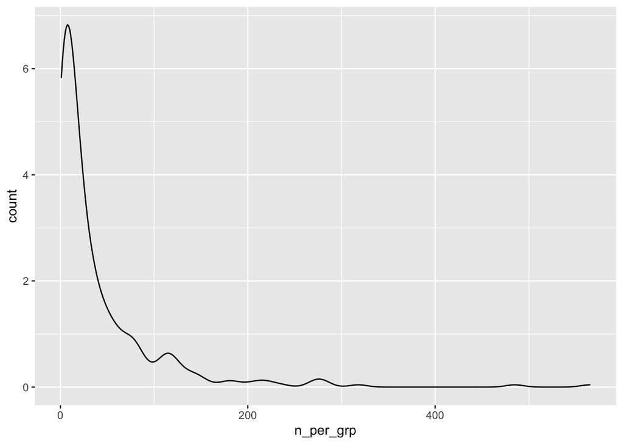

```r
OOS_msa_zip %>% filter(state_code=="TX") %>% ggplot(aes(x = n_per_grp)) + geom_density(aes(y = ..count..))
```

```r
OOS_msa_zip <- OOS_msa_zip %>% mutate(n_per_grp_cat =cut(n_per_grp, breaks=c(0, 1, 20, 100, 565)))

OOS_msa_zip %>% filter(state_code=="TX") %>%
    count(n_per_grp_cat) %>%
    mutate(percent = n / sum(n) * 100)
```

| n_per_grp_cat | n | percent |
| --- | --- | --- |
| (0,1] | 30 | 8.87574 |
| (1,20] | 157 | 46.44970 |
| (20,100] | 111 | 32.84024 |
| (100,565] | 40 | 11.83432 |

- Explore Demographics by Thresholds for TEXAS

```r
# by income
OOS_msa_zip %>% filter(state_code=="TX") %>% group_by(n_per_grp_cat) %>%
select(median_household_income) %>%
      summarise(across(
        .fns = list(mean = mean, sd = sd, min = min, max =max), na.rm = TRUE ))
```

| n_per_grp_cat | median_household_income_mean | median_household_income_sd | median_household_income_min | median_household_income_max |
| --- | --- | --- | --- | --- |
| (0,1] | 57003.83 | 15595.94 | 33294 | 96250 |
| (1,20] | 64844.96 | 19760.08 | 21805 | 128302 |
| (20,100] | 87678.86 | 23005.09 | 47808 | 168611 |
| (100,565] | 114793.23 | 26362.12 | 74363 | 187670 |

```r
# by race
OOS_msa_zip %>% filter(state_code=="TX") %>% group_by(n_per_grp_cat) %>%
select(pct_white) %>%
      summarise(across(
        .fns = list(mean = mean, sd = sd, min = min, max =max), na.rm = TRUE ))
```

| n_per_grp_cat | pct_white_mean | pct_white_sd | pct_white_min | pct_white_max |
| --- | --- | --- | --- | --- |
| (0,1] | 0.4973661 | 0.2204812 | 0.04963473 | 0.8682944 |
| (1,20] | 0.5185078 | 0.2038096 | 0.05168003 | 0.9132184 |
| (20,100] | 0.6159206 | 0.1452845 | 0.22562623 | 0.8728913 |
| (100,565] | 0.6437537 | 0.1371221 | 0.26569660 | 0.9104140 |

## 6.2 California Analyses

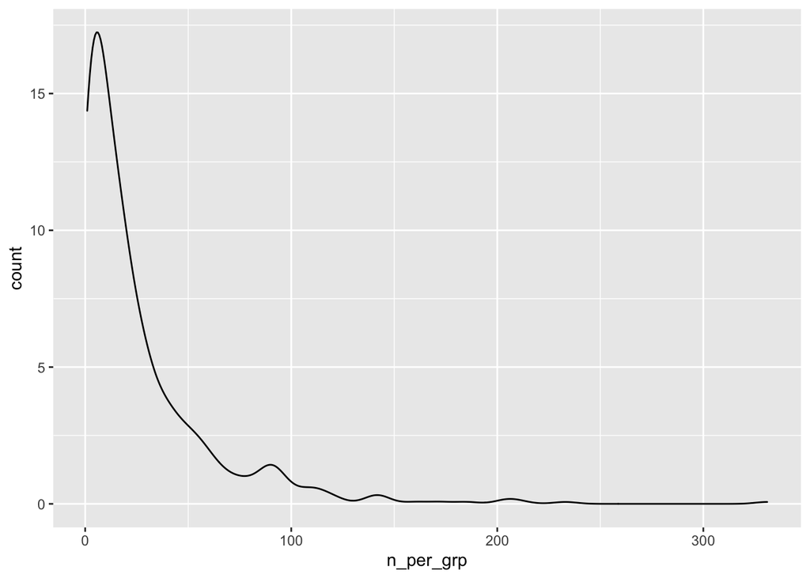

```r
OOS_msa_zip %>% filter(state_code=="CA") %>% ggplot(aes(x = n_per_grp)) + geom_density(aes(y = ..count..))
```

```r
OOS_msa_zip %>% filter(state_code=="CA") %>%
    count(n_per_grp_cat) %>%
    mutate(percent = n / sum(n) * 100)
```

| n_per_grp_cat | n | percent |
| --- | --- | --- |
| (0,1] | 58 | 9.430894 |
| (1,20] | 315 | 51.219512 |
| (20,100] | 216 | 35.121951 |
| (100,565] | 26 | 4.227642 |

- Explore Demographics by Thresholds for CALIFORNIA
  - KS thought: Zip codes in diverse metros may not capture racial variation, need to get at census tract level
  - Coincides with school-level analysis, purchasing only from predominantly White schools in a zip code?

```r
# by income
OOS_msa_zip %>% filter(state_code=="CA") %>% group_by(n_per_grp_cat) %>%
select(median_household_income) %>%
      summarise(across(
        .fns = list(mean = mean, sd = sd, min = min, max =max), na.rm = TRUE ))
```

| n_per_grp_cat | median_household_income_mean | median_household_income_sd | median_household_income_min | median_household_income_max |
| --- | --- | --- | --- | --- |
| (0,1] | 63400.90 | 23742.93 | 26173 | 145705 |
| (1,20] | 77321.33 | 24921.80 | 29456 | 250001 |
| (20,100] | 102120.84 | 29049.19 | 46170 | 243542 |
| (100,565] | 131290.88 | 27826.65 | 90690 | 204534 |

```r
# by race
OOS_msa_zip %>% filter(state_code=="CA") %>% group_by(n_per_grp_cat) %>%
select(pct_white) %>%
      summarise(across(
        .fns = list(mean = mean, sd = sd, min = min, max =max), na.rm = TRUE ))
```

| n_per_grp_cat | pct_white_mean | pct_white_sd | pct_white_min | pct_white_max |
| --- | --- | --- | --- | --- |
| (0,1] | 0.4676439 | 0.2625752 | 0.03548914 | 0.9364486 |
| (1,20] | 0.4821482 | 0.2315415 | 0.02683232 | 1.0000000 |
| (20,100] | 0.5386748 | 0.2018176 | 0.03365227 | 0.8703528 |
| (100,565] | 0.4708332 | 0.1764213 | 0.12242709 | 0.7539145 |

# 7 School district-level exploration

This table below shows the number of students in high schools in California sorted by descending order.

- Grouped at the high school level and summarized to get a count of the number of students purchased within each high school and race/ethnicity
- Merged in NCES data to compare the race/ethnicity of students purchased by high school to the race/ethnicity composition of the school.

```r
# table to display pct poc's purchased by high school compared to pct poc at the high school
df_sl_ca_schools %>%
  dplyr::select(ncessch, name, school_type, n_stu_hs, stu_pct_poc, race_brks_nonwhiteasian_stu, pct_poc, race_brks_nonwhiteasian)
```

| ncessch | name | school_type | n_stu_hs | stu_pct_poc | race_brks_nonwhiteasian_stu | pct_poc | race_brks_nonwhiteasian |
| --- | --- | --- | --- | --- | --- | --- | --- |
| 063513011990 | Dougherty Valley High | Public | 1028 | 3.0499430 | 0-19% | 9.5652 | 0-19% |
| 061440001678 | Mission San Jose High | Public | 697 | 1.2997251 | 0-19% | 2.6304 | 0-19% |
| 061443001699 | Monta Vista High | Public | 667 | 1.6640762 | 0-19% | 2.7577 | 0-19% |
| 063441005643 | Lowell High | Public | 593 | 3.2144961 | 0-19% | 12.9875 | 0-19% |
| 061476001816 | Troy High | Public | 592 | 7.9640389 | 0-19% | 25.5426 | 20-39% |
| 060002009282 | Amador Valley High | Public | 591 | 6.1436865 | 0-19% | 11.8300 | 0-19% |
| 063153012216 | Del Norte High | Public | 521 | 6.5936320 | 0-19% | 13.1401 | 0-19% |
| 064128007894 | Diamond Bar High | Public | 504 | 4.3883980 | 0-19% | 20.4262 | 20-39% |
| 063438011396 | Canyon Crest Academy | Public | 497 | 7.6849281 | 0-19% | 7.7348 | 0-19% |
| 061182010665 | Evergreen Valley High | Public | 464 | 2.3792156 | 0-19% | 20.2678 | 20-39% |

[output cut: 1760 more lines]

Next steps:

- Map high schools onto school district boundaries.
- Perhaps students are purchased within a district, but the frequency of which students are purchased in specific high schools within a school district may vary.